# Homework week 11 day 3 - clustering

You have been provided some customer data from a shopping centre. Do some exploratory analysis on the data. Comment on findings.

We are interested in creating a marketing campaign to target customers based on their spending score and annual income. Perform a k-means clustering to find if there are meaningful clusters in the data to target the customers.

Perform k-means clustering and chose a value of k.

Visualise the clustering for your chosen value of k.

Do you think the clustering seems a good fit for this data?

Comment on the attributes on one or two of the clusters (maybe even give them a label if you like - like in section 4.1 of the ‘Segmentation & clustering intro’ lesson).

## Exploratory analysis

```r
library(tidyverse)
library(janitor)
library(broom)
library(animation)
```

### Load data and check for NAs

```r
customers <- read_csv("data/mall_customers.csv") %>%
  clean_names()

print("NAs  found in data?")
```

```
[1] "NAs  found in data?"
```

```r
any(is.na(customers))
```

```
[1] FALSE
```

### Visualise spending data by age

Not part of the brief, but just having a quick look.

I’ve added a red line to show how this could perhaps be divided into two clusters - younger people tending to have a higher spending score

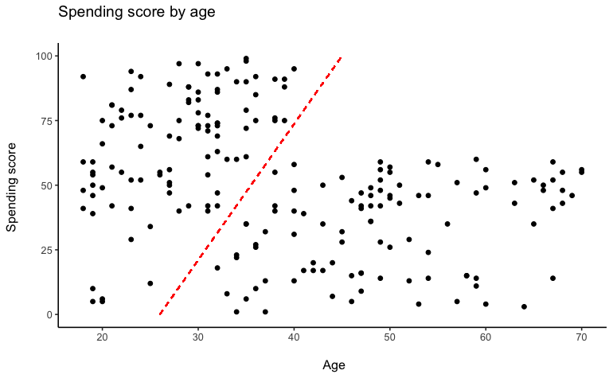

```r
customers %>%
  ggplot() +
  aes(x = age, y = spending_score_1_100) +
  geom_point()+
  theme(panel.grid.major = element_blank(), panel.grid.minor = element_blank(),
panel.background = element_blank(), axis.line = element_line(colour = "black")) +
  geom_segment(aes(x = 26, y = 00, xend = 45, yend = 100), colour = "red", linetype = "dashed") +
  labs(title = "Spending score by age  \n",
       x = "\n Age",
       y = "Spending score \n"
  )
```

### Visualise spending data by income

I’ve added red lines to highlight five clusters which are clear in the data.

These are consistent by gender.

As the groups are very distinct, I would tend to assume this is an educational dataset created specifically for this purpose.

Some notes on the clusters:

- **People earning <40k:** two spending score clusters of 0-40 and 60-100
- **People earning 40-70k:** one spending score cluster of 40-60
- **People earning >70k:** two spending score clusters of 0-40 and 60-100

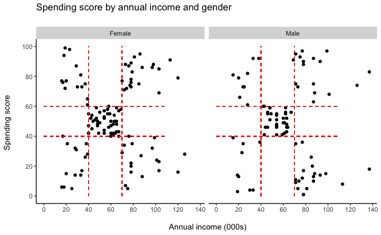

```r
customers %>%
  ggplot() +
  aes(x = annual_income_k, y = spending_score_1_100) +
  geom_point()+
  scale_x_continuous(breaks = c(0, 20, 40, 60, 80, 100, 120, 140, 160)) +
  scale_y_continuous(breaks = c(0, 20, 40, 60, 80, 100)) +
  theme(panel.grid.major = element_blank(), panel.grid.minor = element_blank(),
panel.background = element_blank(), axis.line = element_line(colour = "black")) +
  facet_wrap(~ gender) +
  geom_segment(aes(x = 0, y = 40, xend = 110, yend = 40), colour = "red", linetype = "dashed") +
  geom_segment(aes(x = 0, y = 60, xend = 110, yend = 60), colour = "red", linetype = "dashed") +
    geom_segment(aes(x = 40, y = 0, xend = 40, yend = 100), colour = "red", linetype = "dashed") +
    geom_segment(aes(x = 70, y = 0, xend = 70, yend = 100), colour = "red", linetype = "dashed") +
  labs(title = "Spending score by annual income and gender \n",
       x = "\n Annual income (000s)",
       y = "Spending score \n"
  )
```

## K-means clustering

### Check mean & sd

```r
customers %>%
  summarise(mean_income = round(mean(annual_income_k)),
            sd_income = sd(annual_income_k))
```

| mean_income | sd_income |
| --- | --- |
| 61 | 26.26472 |

```r
customers %>%
  summarise(mean_spending_score = round(mean(spending_score_1_100)),
            sd_spending_score = sd(spending_score_1_100))
```

| mean_spending_score | sd_spending_score |
| --- | --- |
| 50 | 25.82352 |

### Scale the data, check mean & sd again

```r
income_spend_scaled <- customers %>%
  select(annual_income_k, spending_score_1_100) %>%
  mutate_if(is.numeric, scale)
head(income_spend_scaled)
```

| annual_income_k | spending_score_1_100 |
| --- | --- |
| -1.734646 | -0.4337131 |
| -1.734646 | 1.1927111 |
| -1.696572 | -1.7116178 |
| -1.696572 | 1.0378135 |
| -1.658498 | -0.3949887 |
| -1.658498 | 0.9990891 |

```r
income_spend_scaled %>%
  summarise(mean_income = round(mean(annual_income_k)),
            sd_income = sd(annual_income_k))
```

| mean_income | sd_income |
| --- | --- |
| 0 | 1 |

```r
income_spend_scaled %>%
  summarise(mean_spending_score = round(mean(spending_score_1_100)),
            sd_spending_score = sd(spending_score_1_100))
```

| mean_spending_score | sd_spending_score |
| --- | --- |
| 0 | 1 |

### Generate clusters

I’m creating five clusters, based on the plots I created in my exploratory analysis.

```r
income_spend_clustered <- kmeans(income_spend_scaled,
                                 centers  = 5, nstart = 25)

tidy(income_spend_clustered,
     col.names = colnames(income_spend_scaled))
```

| annual_income_k | spending_score_1_100 | size | withinss | cluster |
| --- | --- | --- | --- | --- |
| -0.2004097 | -0.02638995 | 81 | 14.485632 | 1 |
| -1.3262173 | 1.12934389 | 22 | 5.217630 | 2 |
| 1.0523622 | -1.28122394 | 35 | 18.304646 | 3 |
| -1.3042458 | -1.13411939 | 23 | 7.577407 | 4 |
| 0.9891010 | 1.23640011 | 39 | 19.655252 | 5 |

### Add cluster number to observations in the original data

I’m making this into a new table which I may use for deciding which customers to target

*?? why is this showing different figures when I knit it*

```r
customer_with_cluster <-
augment(income_spend_clustered, customers)
```

```r
# Manually create a static version - temp fix so clusters are not re-run and assigned different number codes
#customer_with_cluster_static <- tibble(customer_with_cluster)

# code below doesn't work properly - number codes are reassigned each time cluster code is run, so the wrong cluster names are applied

customer_with_cluster_static <- customer_with_cluster_static %>%
  #rename("cluster" = ".cluster") %>%
  mutate(cluster_name = recode(cluster, "1"  = "Mid income, mid spend",
                               "2" = "Lower income, high spend",
                               "3" = "High income, low spend",
                               "4" = "Lower income, low spend",
                               "5" = "High income, high spend",))

customer_with_cluster_static  %>%
  group_by(cluster, cluster_name) %>%
  summarise(avg_income = mean(annual_income_k),
            avg_spending_score = mean(spending_score_1_100)) %>%
  arrange(avg_income)
```

| cluster | cluster_name | avg_income | avg_spending_score |
| --- | --- | --- | --- |
| 2 | Lower income, high spend | 25.72727 | 79.36364 |
| 4 | Lower income, low spend | 26.30435 | 20.91304 |
| 1 | Mid income, mid spend | 55.29630 | 49.51852 |
| 5 | High income, high spend | 86.53846 | 82.12821 |
| 3 | High income, low spend | 88.20000 | 17.11429 |

```r
NA
```

### Visualise the clusters

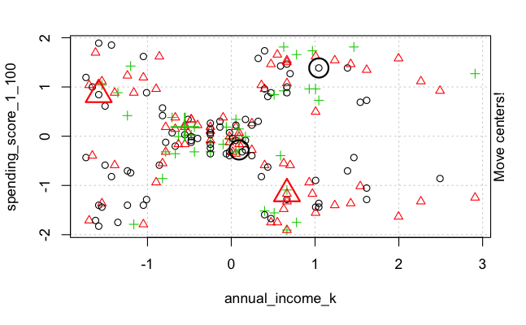

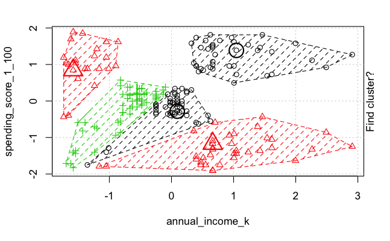

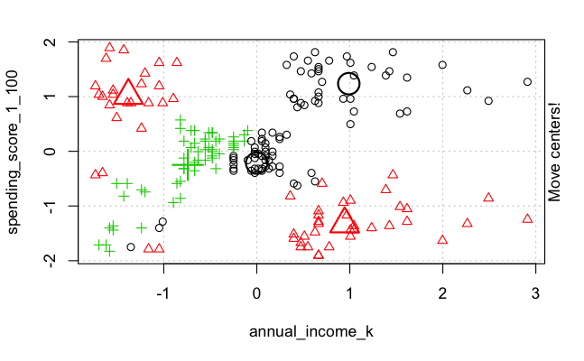

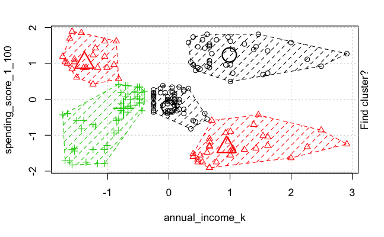

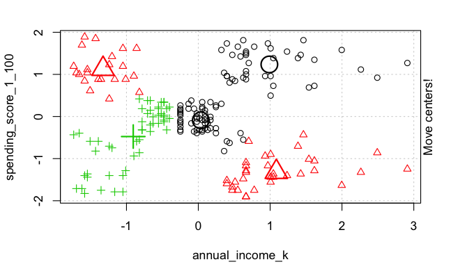

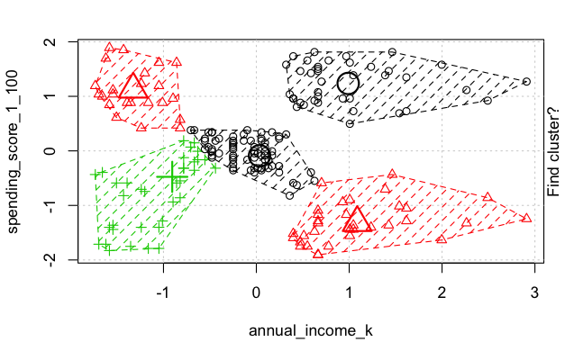

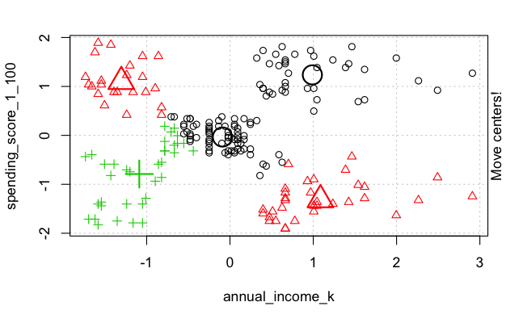

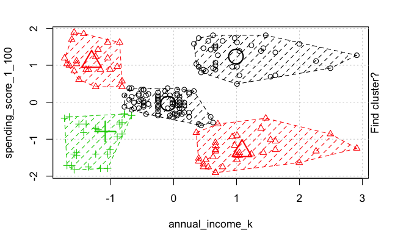

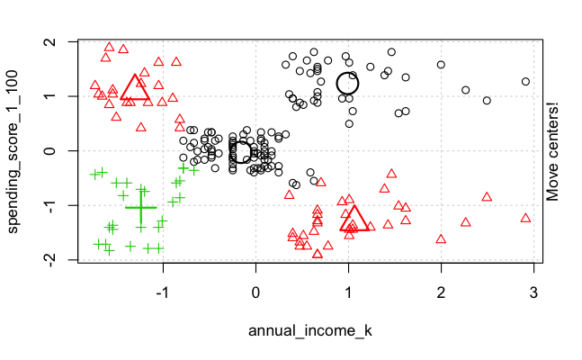

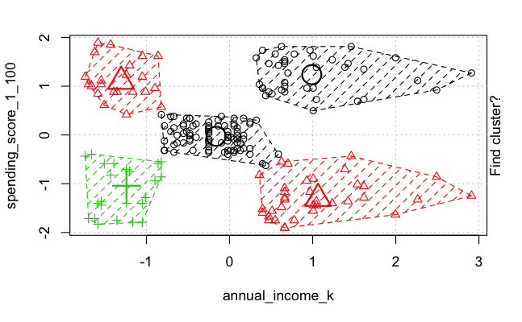

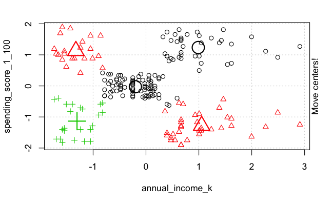

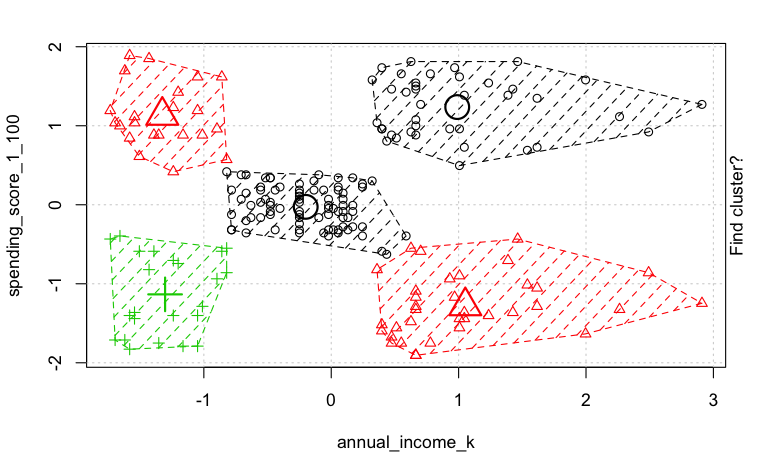

```r
income_spend_scaled %>%
  kmeans.ani(centers = 5)
```

### Check that I’m using the optimal number of clusters

This is pretty clear for this dataset, but doing it for practice.

The *elbow point* of the graph is 5, which ties up with the intitial exploritary analysis of the data

```r
glance(income_spend_clustered)
```

| totss | tot.withinss | betweenss | iter |
| --- | --- | --- | --- |
| 398 | 65.24057 | 332.7594 | 3 |

```r
max_k <- 20

k_clusters <- tibble(k = 1:max_k) %>%
  mutate(
    kclust = map(k, ~ kmeans(income_spend_scaled, .x, nstart = 25)),
    tidied = map(kclust, tidy),
    glanced = map(kclust, glance),
    augmented = map(kclust, augment, customers)
  )

head(k_clusters,3)
```

| k | kclust | tidied | glanced | augmented |
| --- | --- | --- | --- | --- |
| 1 |  |  |  |  |
| 2 |  |  |  |  |
| 3 |  |  |  |  |

```r
clusterings <- k_clusters %>%
  unnest(glanced)

head(clusterings,3)
```

| k | kclust | tidied | totss | tot.withinss | betweenss | iter | augmented |
| --- | --- | --- | --- | --- | --- | --- | --- |
| 1 |  |  | 398 | 398.0000 | -2.273737e-13 | 1 |  |
| 2 |  |  | 398 | 267.7968 | 1.302032e+02 | 1 |  |
| 3 |  |  | 398 | 156.9155 | 2.410845e+02 | 3 |  |

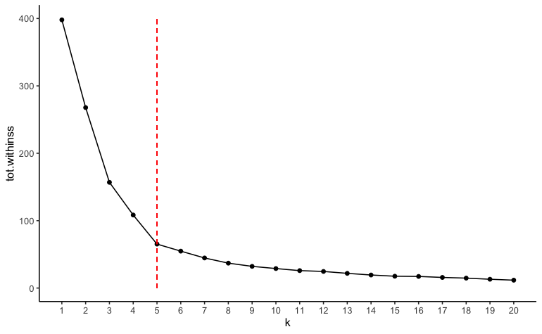

```r
ggplot(clusterings, aes(x=k, y=tot.withinss)) +
  geom_point() +
    geom_line() +
  theme(panel.grid.major = element_blank(), panel.grid.minor = element_blank(),
panel.background = element_blank(), axis.line = element_line(colour = "black")) +
    scale_x_continuous(breaks = seq(1, 20, by = 1)) +
      geom_segment(aes(x = 5, y = 0, xend = 5, yend = 400), colour = "red", linetype = "dashed")
```

## Commentary and insights

Clustering is a good fit for this dataset, which has clearly-defined groupings, already clearly visible in a simple scatter plot even before performing further analysis.

The clusters are summarised in the output below - points to note which may be useful when deciding which customers to target:

```r
customer_with_cluster_static  %>%
  group_by(cluster_name) %>%
  summarise(number_of_customers = n(),
            avg_income = mean(annual_income_k),
            avg_spending_score = mean(spending_score_1_100)) %>%
  arrange(avg_income)
```

| cluster_name | number_of_customers | avg_income | avg_spending_score |
| --- | --- | --- | --- |
| Lower income, high spend | 22 | 25.72727 | 79.36364 |
| Lower income, low spend | 23 | 26.30435 | 20.91304 |
| Mid income, mid spend | 81 | 55.29630 | 49.51852 |
| High income, high spend | 39 | 86.53846 | 82.12821 |
| High income, low spend | 35 | 88.20000 | 17.11429 |

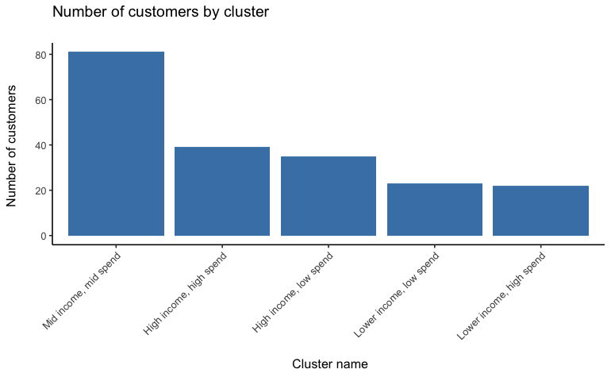

```r
customer_with_cluster_static %>%
group_by(cluster_name) %>%
summarise(number_of_customers = n()) %>%
  ggplot() +
  aes(x = reorder(cluster_name, -number_of_customers), y = number_of_customers) +
  theme(panel.grid.major = element_blank(), panel.grid.minor = element_blank(),
panel.background = element_blank(), axis.line = element_line(colour = "black")) +
  theme(axis.text.x = element_text(angle=45,hjust=1)) +
  geom_col(fill = "steel blue") +
   labs(title = "Number of customers by cluster \n",
       x = "\n Cluster name",
       y = "Number of customers \n"
  )
```